# ANCOVA in Vocabulario Não Ensinado (Vocabulario Não Ensinado)

Geiser C. Challco geiser@alumni.usp.br

- Descriptive Statistics of Initial Data
- ANCOVA and Pairwise for one factor: **grupo**
  - Without remove non-normal data
  - Computing ANCOVA and PairWise After removing non-normal data (OK)
    - Plots for ancova
    - Checking linearity assumption
    - Checking normality and homogeneity
- ANCOVA and Pairwise for two factors **grupo:Sexo**
  - Without remove non-normal data
  - Computing ANCOVA and PairWise After removing non-normal data (OK)
    - Plots for ancova
    - Checking linearity assumption
    - Checking normality and homogeneity
- ANCOVA and Pairwise for two factors **grupo:Zona**
  - Without remove non-normal data
  - Computing ANCOVA and PairWise After removing non-normal data (OK)
    - Plots for ancova
    - Checking linearity assumption
    - Checking normality and homogeneity
- ANCOVA and Pairwise for two factors **grupo:Cor.Raca**
  - Without remove non-normal data
  - Computing ANCOVA and PairWise After removing non-normal data (OK)
    - Plots for ancova
    - Checking linearity assumption
    - Checking normality and homogeneity
- ANCOVA and Pairwise for two factors **grupo:vocab.non.teach.quintile**
  - Without remove non-normal data
  - Computing ANCOVA and PairWise After removing non-normal data (OK)
    - Plots for ancova
    - Checking linearity assumption
    - Checking normality and homogeneity
- Summary of Results
  - Descriptive Statistics
  - ANCOVA Table Comparison
  - PairWise Table Comparison
  - EMMS Table Comparison

**NOTE**:

- Teste ANCOVA para determinar se houve diferenças significativas no Vocabulario Não Ensinado (medido usando pre- e pos-testes).
- ANCOVA test to determine whether there were significant differences in Vocabulario Não Ensinado (measured using pre- and post-tests).

# Descriptive Statistics of Initial Data

```r
df <- get.descriptives(dat, c(dv.pre, dv.pos), c("grupo"),
                       include.global = T, symmetry.test = T, normality.test = F)
df <- plyr::rbind.fill(
  df, do.call(plyr::rbind.fill, lapply(lfatores2, FUN = function(f) {
    if (nrow(dat) > 0 && sum(!is.na(unique(dat[[f]]))) > 1)
      get.descriptives(dat, c(dv.pre,dv.pos), c("grupo", f),
                       symmetry.test = T, normality.test = F)
    }))
)
(df <- df[,c(fatores1[fatores1 %in% colnames(df)],"variable",
             colnames(df)[!colnames(df) %in% c(fatores1,"variable")])])
```

```
##           grupo Sexo   Zona Cor.Raca vocab.non.teach.quintile            variable   n   mean median min max
## 1      Controle <NA>   <NA>     <NA>                     <NA> vocab.non.teach.pre 152 20.467   20.0   4  35
## 2  Experimental <NA>   <NA>     <NA>                     <NA> vocab.non.teach.pre 196 21.903   22.0   4  35
## 3          <NA> <NA>   <NA>     <NA>                     <NA> vocab.non.teach.pre 348 21.276   22.0   4  35
## 4      Controle <NA>   <NA>     <NA>                     <NA> vocab.non.teach.pos 152 21.474   23.0   5  37
## 5  Experimental <NA>   <NA>     <NA>                     <NA> vocab.non.teach.pos 196 21.852   22.0   4  35
## 6          <NA> <NA>   <NA>     <NA>                     <NA> vocab.non.teach.pos 348 21.687   22.0   4  37
## 7      Controle    F   <NA>     <NA>                     <NA> vocab.non.teach.pre  85 21.459   22.0   6  35
## 8      Controle    M   <NA>     <NA>                     <NA> vocab.non.teach.pre  67 19.209   18.0   4  34
## 9  Experimental    F   <NA>     <NA>                     <NA> vocab.non.teach.pre  98 21.806   22.0   9  33
## 10 Experimental    M   <NA>     <NA>                     <NA> vocab.non.teach.pre  98 22.000   22.5   4  35
## 11     Controle    F   <NA>     <NA>                     <NA> vocab.non.teach.pos  85 22.565   24.0   5  35
## 12     Controle    M   <NA>     <NA>                     <NA> vocab.non.teach.pos  67 20.090   20.0   5  37
## 13 Experimental    F   <NA>     <NA>                     <NA> vocab.non.teach.pos  98 22.704   23.0   5  35
## 14 Experimental    M   <NA>     <NA>                     <NA> vocab.non.teach.pos  98 21.000   21.5   4  35
```

[output cut: 98 more lines]

| grupo | Sexo | Zona | Cor.Raca | vocab.non.teach.quintile | variable | n | mean | median | min | max | sd | se | ci | iqr | symmetry | skewness | kurtosis |
| --- | --- | --- | --- | --- | --- | --- | --- | --- | --- | --- | --- | --- | --- | --- | --- | --- | --- |
| Controle |  |  |  |  | vocab.non.teach.pre | 152 | 20.467 | 20.0 | 4 | 35 | 7.433 | 0.603 | 1.191 | 11.25 | YES | -0.124 | -0.928 |
| Experimental |  |  |  |  | vocab.non.teach.pre | 196 | 21.903 | 22.0 | 4 | 35 | 6.555 | 0.468 | 0.923 | 10.00 | YES | -0.218 | -0.680 |
|  |  |  |  |  | vocab.non.teach.pre | 348 | 21.276 | 22.0 | 4 | 35 | 6.978 | 0.374 | 0.736 | 11.00 | YES | -0.205 | -0.760 |
| Controle |  |  |  |  | vocab.non.teach.pos | 152 | 21.474 | 23.0 | 5 | 37 | 7.466 | 0.606 | 1.197 | 11.00 | YES | -0.244 | -0.763 |
| Experimental |  |  |  |  | vocab.non.teach.pos | 196 | 21.852 | 22.0 | 4 | 35 | 7.076 | 0.505 | 0.997 | 11.00 | YES | -0.416 | -0.609 |
|  |  |  |  |  | vocab.non.teach.pos | 348 | 21.687 | 22.0 | 4 | 37 | 7.241 | 0.388 | 0.763 | 10.00 | YES | -0.340 | -0.670 |
| Controle | F |  |  |  | vocab.non.teach.pre | 85 | 21.459 | 22.0 | 6 | 35 | 7.001 | 0.759 | 1.510 | 11.00 | YES | -0.136 | -0.906 |
| Controle | M |  |  |  | vocab.non.teach.pre | 67 | 19.209 | 18.0 | 4 | 34 | 7.819 | 0.955 | 1.907 | 14.00 | YES | -0.023 | -1.071 |
| Experimental | F |  |  |  | vocab.non.teach.pre | 98 | 21.806 | 22.0 | 9 | 33 | 6.296 | 0.636 | 1.262 | 9.00 | YES | -0.063 | -0.902 |
| Experimental | M |  |  |  | vocab.non.teach.pre | 98 | 22.000 | 22.5 | 4 | 35 | 6.835 | 0.690 | 1.370 | 10.00 | YES | -0.342 | -0.571 |
| Controle | F |  |  |  | vocab.non.teach.pos | 85 | 22.565 | 24.0 | 5 | 35 | 6.771 | 0.734 | 1.460 | 10.00 | YES | -0.405 | -0.493 |
| Controle | M |  |  |  | vocab.non.teach.pos | 67 | 20.090 | 20.0 | 5 | 37 | 8.107 | 0.990 | 1.977 | 13.00 | YES | 0.020 | -0.991 |
| Experimental | F |  |  |  | vocab.non.teach.pos | 98 | 22.704 | 23.0 | 5 | 35 | 6.494 | 0.656 | 1.302 | 9.00 | NO | -0.561 | -0.304 |
| Experimental | M |  |  |  | vocab.non.teach.pos | 98 | 21.000 | 21.5 | 4 | 35 | 7.552 | 0.763 | 1.514 | 11.75 | YES | -0.240 | -0.866 |
| Controle |  | Rural |  |  | vocab.non.teach.pre | 77 | 20.948 | 22.0 | 6 | 34 | 7.104 | 0.810 | 1.612 | 11.00 | YES | -0.167 | -1.072 |
| Controle |  | Urbana |  |  | vocab.non.teach.pre | 50 | 21.840 | 22.0 | 4 | 35 | 7.560 | 1.069 | 2.149 | 12.50 | YES | -0.228 | -0.908 |
| Controle |  |  |  |  | vocab.non.teach.pre | 25 | 16.240 | 16.0 | 4 | 31 | 6.912 | 1.382 | 2.853 | 9.00 | YES | 0.123 | -0.783 |
| Experimental |  | Rural |  |  | vocab.non.teach.pre | 92 | 21.924 | 23.0 | 4 | 33 | 6.878 | 0.717 | 1.424 | 10.00 | YES | -0.302 | -0.571 |
| Experimental |  | Urbana |  |  | vocab.non.teach.pre | 75 | 22.427 | 23.0 | 8 | 35 | 6.219 | 0.718 | 1.431 | 9.50 | YES | -0.173 | -0.760 |
| Experimental |  |  |  |  | vocab.non.teach.pre | 29 | 20.483 | 21.0 | 11 | 31 | 6.362 | 1.181 | 2.420 | 10.00 | YES | 0.033 | -1.353 |
| Controle |  | Rural |  |  | vocab.non.teach.pos | 77 | 22.091 | 23.0 | 6 | 36 | 7.233 | 0.824 | 1.642 | 9.00 | YES | -0.321 | -0.663 |
| Controle |  | Urbana |  |  | vocab.non.teach.pos | 50 | 22.200 | 24.0 | 5 | 37 | 7.884 | 1.115 | 2.241 | 11.75 | YES | -0.477 | -0.652 |
| Controle |  |  |  |  | vocab.non.teach.pos | 25 | 18.120 | 16.0 | 8 | 32 | 6.642 | 1.328 | 2.741 | 8.00 | YES | 0.430 | -0.611 |
| Experimental |  | Rural |  |  | vocab.non.teach.pos | 92 | 21.522 | 22.0 | 4 | 35 | 7.098 | 0.740 | 1.470 | 10.00 | YES | -0.378 | -0.472 |
| Experimental |  | Urbana |  |  | vocab.non.teach.pos | 75 | 22.520 | 24.0 | 7 | 35 | 6.888 | 0.795 | 1.585 | 10.00 | NO | -0.528 | -0.678 |
| Experimental |  |  |  |  | vocab.non.teach.pos | 29 | 21.172 | 21.0 | 5 | 33 | 7.588 | 1.409 | 2.886 | 13.00 | YES | -0.216 | -1.058 |
| Controle |  |  | Branca |  | vocab.non.teach.pre | 22 | 22.273 | 22.5 | 11 | 34 | 6.423 | 1.369 | 2.848 | 8.75 | YES | 0.006 | -1.095 |
| Controle |  |  | Indígena |  | vocab.non.teach.pre | 8 | 20.375 | 21.5 | 11 | 27 | 5.423 | 1.917 | 4.534 | 5.50 | NO | -0.532 | -1.310 |
| Controle |  |  | Parda |  | vocab.non.teach.pre | 44 | 18.864 | 18.0 | 5 | 31 | 7.395 | 1.115 | 2.248 | 13.00 | YES | 0.103 | -1.284 |
| Controle |  |  |  |  | vocab.non.teach.pre | 78 | 20.872 | 21.5 | 4 | 35 | 7.830 | 0.887 | 1.765 | 11.75 | YES | -0.212 | -0.891 |
| Experimental |  |  | Branca |  | vocab.non.teach.pre | 12 | 22.167 | 23.5 | 13 | 33 | 6.206 | 1.792 | 3.943 | 8.00 | YES | -0.115 | -1.185 |
| Experimental |  |  | Indígena |  | vocab.non.teach.pre | 2 | 20.000 | 20.0 | 15 | 25 | 7.071 | 5.000 | 63.531 | 5.00 | few data | 0.000 | 0.000 |
| Experimental |  |  | Parda |  | vocab.non.teach.pre | 52 | 20.481 | 19.5 | 9 | 33 | 6.491 | 0.900 | 1.807 | 11.00 | YES | 0.100 | -1.096 |
| Experimental |  |  |  |  | vocab.non.teach.pre | 130 | 22.477 | 23.0 | 4 | 35 | 6.589 | 0.578 | 1.143 | 10.00 | YES | -0.364 | -0.424 |
| Controle |  |  | Branca |  | vocab.non.teach.pos | 22 | 23.500 | 24.0 | 11 | 36 | 6.603 | 1.408 | 2.927 | 9.50 | YES | -0.024 | -0.776 |
| Controle |  |  | Indígena |  | vocab.non.teach.pos | 8 | 23.000 | 22.0 | 12 | 32 | 6.547 | 2.315 | 5.473 | 7.50 | YES | -0.150 | -1.332 |
| Controle |  |  | Parda |  | vocab.non.teach.pos | 44 | 20.545 | 21.5 | 5 | 37 | 8.398 | 1.266 | 2.553 | 13.00 | YES | -0.147 | -1.183 |
| Controle |  |  |  |  | vocab.non.teach.pos | 78 | 21.269 | 21.5 | 5 | 35 | 7.225 | 0.818 | 1.629 | 9.75 | YES | -0.249 | -0.739 |
| Experimental |  |  | Branca |  | vocab.non.teach.pos | 12 | 19.167 | 18.5 | 8 | 30 | 6.162 | 1.779 | 3.915 | 6.50 | YES | 0.061 | -0.942 |
| Experimental |  |  | Indígena |  | vocab.non.teach.pos | 2 | 21.000 | 21.0 | 15 | 27 | 8.485 | 6.000 | 76.237 | 6.00 | few data | 0.000 | 0.000 |
| Experimental |  |  | Parda |  | vocab.non.teach.pos | 52 | 20.615 | 21.5 | 5 | 31 | 6.411 | 0.889 | 1.785 | 9.25 | YES | -0.411 | -0.544 |
| Experimental |  |  |  |  | vocab.non.teach.pos | 130 | 22.608 | 24.0 | 4 | 35 | 7.333 | 0.643 | 1.273 | 10.75 | NO | -0.537 | -0.563 |
| Controle |  |  |  | 1st quintile | vocab.non.teach.pre | 31 | 10.000 | 11.0 | 4 | 13 | 2.671 | 0.480 | 0.980 | 3.00 | NO | -0.935 | -0.293 |
| Controle |  |  |  | 2nd quintile | vocab.non.teach.pre | 39 | 16.513 | 16.0 | 14 | 19 | 1.571 | 0.252 | 0.509 | 2.50 | YES | 0.017 | -1.095 |
| Controle |  |  |  | 3rd quintile | vocab.non.teach.pre | 31 | 22.290 | 23.0 | 20 | 24 | 1.553 | 0.279 | 0.570 | 3.00 | YES | -0.368 | -1.449 |
| Controle |  |  |  | 4th quintile | vocab.non.teach.pre | 30 | 26.933 | 27.0 | 25 | 29 | 1.574 | 0.287 | 0.588 | 3.50 | YES | 0.106 | -1.560 |
| Controle |  |  |  | 5th quintile | vocab.non.teach.pre | 21 | 31.333 | 31.0 | 30 | 35 | 1.528 | 0.333 | 0.695 | 1.00 | NO | 1.063 | -0.205 |
| Experimental |  |  |  | 1st quintile | vocab.non.teach.pre | 25 | 11.000 | 12.0 | 4 | 13 | 2.398 | 0.480 | 0.990 | 2.00 | NO | -1.567 | 1.755 |
| Experimental |  |  |  | 2nd quintile | vocab.non.teach.pre | 45 | 16.733 | 17.0 | 14 | 19 | 1.587 | 0.237 | 0.477 | 3.00 | YES | -0.103 | -1.322 |
| Experimental |  |  |  | 3rd quintile | vocab.non.teach.pre | 52 | 22.019 | 22.0 | 20 | 24 | 1.276 | 0.177 | 0.355 | 2.00 | YES | -0.091 | -1.260 |
| Experimental |  |  |  | 4th quintile | vocab.non.teach.pre | 47 | 26.957 | 27.0 | 25 | 29 | 1.414 | 0.206 | 0.415 | 2.00 | YES | -0.017 | -1.366 |
| Experimental |  |  |  | 5th quintile | vocab.non.teach.pre | 27 | 31.593 | 32.0 | 30 | 35 | 1.309 | 0.252 | 0.518 | 2.00 | YES | 0.450 | -0.419 |
| Controle |  |  |  | 1st quintile | vocab.non.teach.pos | 31 | 13.484 | 14.0 | 5 | 22 | 4.618 | 0.829 | 1.694 | 7.00 | YES | -0.015 | -1.104 |
| Controle |  |  |  | 2nd quintile | vocab.non.teach.pos | 39 | 17.667 | 17.0 | 5 | 27 | 5.362 | 0.859 | 1.738 | 7.00 | YES | -0.329 | -0.311 |
| Controle |  |  |  | 3rd quintile | vocab.non.teach.pos | 31 | 23.129 | 24.0 | 10 | 32 | 4.653 | 0.836 | 1.707 | 5.00 | NO | -0.590 | 0.540 |
| Controle |  |  |  | 4th quintile | vocab.non.teach.pos | 30 | 27.433 | 27.0 | 22 | 37 | 3.191 | 0.583 | 1.192 | 5.00 | NO | 0.657 | 0.546 |
| Controle |  |  |  | 5th quintile | vocab.non.teach.pos | 21 | 29.381 | 31.0 | 9 | 36 | 6.054 | 1.321 | 2.756 | 3.00 | NO | -1.977 | 3.879 |
| Experimental |  |  |  | 1st quintile | vocab.non.teach.pos | 25 | 12.280 | 12.0 | 4 | 24 | 4.852 | 0.970 | 2.003 | 6.00 | YES | 0.401 | -0.446 |
| Experimental |  |  |  | 2nd quintile | vocab.non.teach.pos | 45 | 17.400 | 18.0 | 5 | 27 | 5.043 | 0.752 | 1.515 | 7.00 | NO | -0.506 | -0.355 |
| Experimental |  |  |  | 3rd quintile | vocab.non.teach.pos | 52 | 23.135 | 23.0 | 11 | 31 | 4.883 | 0.677 | 1.359 | 6.00 | YES | -0.293 | -0.498 |
| Experimental |  |  |  | 4th quintile | vocab.non.teach.pos | 47 | 25.936 | 27.0 | 10 | 34 | 4.660 | 0.680 | 1.368 | 6.50 | NO | -0.946 | 1.197 |
| Experimental |  |  |  | 5th quintile | vocab.non.teach.pos | 27 | 28.556 | 29.0 | 14 | 35 | 4.807 | 0.925 | 1.901 | 4.00 | NO | -1.409 | 1.914 |

# ANCOVA and Pairwise for one factor: **grupo**

## Without remove non-normal data

```r
pdat = remove_group_data(dat[!is.na(dat[["grupo"]]),], "vocab.non.teach.pos", "grupo")

pdat.long <- rbind(pdat[,c("id","grupo")], pdat[,c("id","grupo")])
pdat.long[["time"]] <- c(rep("pre", nrow(pdat)), rep("pos", nrow(pdat)))
pdat.long[["time"]] <- factor(pdat.long[["time"]], c("pre","pos"))
pdat.long[["vocab.non.teach"]] <- c(pdat[["vocab.non.teach.pre"]], pdat[["vocab.non.teach.pos"]])

aov = anova_test(pdat, vocab.non.teach.pos ~ vocab.non.teach.pre + grupo)
laov[["grupo"]] <- get_anova_table(aov)
```

```r
pwc <- emmeans_test(pdat, vocab.non.teach.pos ~ grupo, covariate = vocab.non.teach.pre,
                    p.adjust.method = "bonferroni")
```

```r
pwc.long <- emmeans_test(dplyr::group_by_at(pdat.long, "grupo"),
                          vocab.non.teach ~ time,
                          p.adjust.method = "bonferroni")
lpwc[["grupo"]] <- plyr::rbind.fill(pwc, pwc.long)
```

```r
ds <- get.descriptives(pdat, "vocab.non.teach.pos", "grupo", covar = "vocab.non.teach.pre")
ds <- merge(ds[ds$variable != "vocab.non.teach.pre",],
            ds[ds$variable == "vocab.non.teach.pre", !colnames(ds) %in% c("variable")],
            by = "grupo", all.x = T, suffixes = c("", ".vocab.non.teach.pre"))
ds <- merge(get_emmeans(pwc), ds, by = "grupo", suffixes = c(".emms", ""))
ds <- ds[,c("grupo","n","mean.vocab.non.teach.pre","se.vocab.non.teach.pre","mean","se","emmean","se.emms")]

colnames(ds) <- c("grupo", "N", paste0(c("M","SE")," (pre)"),
                  paste0(c("M","SE"), " (unadj)"), paste0(c("M", "SE"), " (adj)"))

lemms[["grupo"]] <- ds
```

## Computing ANCOVA and PairWise After removing non-normal data (OK)

```r
wdat = pdat

res = residuals(lm(vocab.non.teach.pos ~ vocab.non.teach.pre + grupo, data = wdat))
non.normal = getNonNormal(res, wdat$id, plimit = 0.05)

wdat = wdat[!wdat$id %in% non.normal,]

wdat.long <- rbind(wdat[,c("id","grupo")], wdat[,c("id","grupo")])
wdat.long[["time"]] <- c(rep("pre", nrow(wdat)), rep("pos", nrow(wdat)))
wdat.long[["time"]] <- factor(wdat.long[["time"]], c("pre","pos"))
wdat.long[["vocab.non.teach"]] <- c(wdat[["vocab.non.teach.pre"]], wdat[["vocab.non.teach.pos"]])

ldat[["grupo"]] = wdat

(non.normal)
```

```
##   [1] "P983"  "P1966" "P3042" "P1936" "P1831" "P1961" "P3097" "P2957" "P976"  "P916"  "P1969" "P2955" "P1907"
##  [14] "P3561" "P1989" "P3078" "P1982" "P3586" "P1939" "P3571" "P3535" "P3080" "P2002" "P3534" "P1826" "P3580"
##  [27] "P1954" "P1854" "P3025" "P1955" "P917"  "P3029" "P910"  "P3574" "P3009" "P1897" "P3573" "P1869" "P3067"
##  [40] "P940"  "P937"  "P1958" "P932"  "P955"  "P1985" "P3053" "P1863" "P1944" "P926"  "P3069" "P1997" "P3103"
##  [53] "P920"  "P2011" "P2980" "P546"  "P2999" "P2005" "P1948" "P1851" "P3556" "P2989" "P536"  "P3017" "P3102"
##  [66] "P963"  "P2967" "P1880" "P3591" "P1837" "P1857" "P525"  "P1959" "P988"  "P2962" "P1979" "P986"  "P3584"
##  [79] "P1905" "P2008" "P544"  "P1935" "P1973" "P526"  "P3012" "P1853" "P3572" "P2970" "P1830" "P3088" "P3033"
##  [92] "P3066" "P3011" "P3038" "P511"  "P1842" "P1883" "P3582" "P3568" "P1978" "P1828" "P1968" "P2009" "P3074"
## [105] "P3062" "P3529" "P1990" "P1988" "P3528" "P1876" "P1903" "P1829" "P967"  "P938"  "P2986" "P972"  "P3567"
## [118] "P913"  "P1825" "P548"  "P1991" "P2953" "P518"  "P520"  "P1849" "P1949" "P538"  "P3554" "P3551" "P1870"
## [131] "P3540" "P1888" "P1884" "P2952" "P1974" "P944"  "P1879" "P2984" "P2997" "P3590" "P1910" "P3003" "P1914"
## [144] "P1848" "P919"  "P1840" "P911"  "P931"  "P3082" "P2945" "P2978" "P939"  "P3532" "P928"  "P552"  "P2003"
## [157] "P3549" "P1913" "P3079" "P2973" "P3064" "P3007" "P1920" "P3536" "P1908" "P970"  "P3021" "P2948" "P1885"
## [170] "P905"  "P975"  "P3077" "P929"  "P3085" "P1846" "P1915" "P1833" "P924"  "P1950" "P3059" "P3589" "P3563"
## [183] "P3588" "P2956" "P1855" "P935"  "P524"  "P1878" "P1921" "P1868" "P909"  "P3576" "P980"  "P2990" "P3048"
## [196] "P1887" "P3015" "P954"  "P3068" "P3546" "P1900" "P1886" "P3570" "P1943" "P1902" "P1892" "P1912" "P3024"
## [209] "P3006" "P3026" "P3579" "P2964" "P2947" "P971"  "P2950" "P914"  "P1867" "P2969" "P3530" "P927"  "P3531"
## [222] "P3020" "P2966" "P2971" "P1891" "P1925" "P3587" "P1882" "P3054" "P1852" "P1911" "P1895" "P982"  "P545"
## [235] "P1841" "P3526" "P987"  "P3010" "P961"  "P535"  "P3057" "P2946" "P3083" "P3030" "P978"  "P969"  "P3543"
## [248] "P549"  "P3065" "P974"  "P962"  "P1916" "P1956" "P3073" "P2968" "P1975" "P3086" "P918"  "P3076" "P2961"
## [261] "P949"  "P966"  "P1843" "P1922" "P1906" "P907"  "P1832" "P3550" "P1875" "P979"  "P2951" "P1847" "P3562"
## [274] "P1987" "P3585" "P2981" "P973"  "P3050" "P925"  "P1893" "P534"  "P1947" "P3542" "P1877" "P2982" "P930"
## [287] "P959"  "P3005" "P3070" "P3095" "P2012" "P1862" "P3533" "P3111" "P539"  "P1901" "P3110" "P1844" "P541"
## [300] "P1998" "P951"  "P1834" "P543"  "P1976" "P915"  "P3541"
```

```r
aov = anova_test(wdat, vocab.non.teach.pos ~ vocab.non.teach.pre + grupo)
laov[["grupo"]] <- merge(get_anova_table(aov), laov[["grupo"]], by="Effect", suffixes = c("","'"))

(df = get_anova_table(aov))
```

```
## ANOVA Table (type II tests)
##
##                Effect DFn DFd       F        p p<.05   ges
## 1 vocab.non.teach.pre   1  39 379.844 1.05e-21     * 0.907
## 2               grupo   1  39   0.396 5.33e-01       0.010
```

| Effect | DFn | DFd | F | p | p<.05 | ges |
| --- | --- | --- | --- | --- | --- | --- |
| vocab.non.teach.pre | 1 | 39 | 379.844 | 0.000 | * | 0.907 |
| grupo | 1 | 39 | 0.396 | 0.533 |  | 0.010 |

| term | .y. | group1 | group2 | df | statistic | p | p.adj | p.adj.signif |
| --- | --- | --- | --- | --- | --- | --- | --- | --- |
| vocab.non.teach.pre*grupo | vocab.non.teach.pos | Controle | Experimental | 39 | 0.629 | 0.533 | 0.533 | ns |

```r
pwc.long <- emmeans_test(dplyr::group_by_at(wdat.long, "grupo"),
                         vocab.non.teach ~ time,
                         p.adjust.method = "bonferroni")
lpwc[["grupo"]] <- merge(plyr::rbind.fill(pwc, pwc.long), lpwc[["grupo"]], by=c("grupo","term",".y.","group1","group2"), suffixes = c("","'"))
```

| grupo | term | .y. | group1 | group2 | df | statistic | p | p.adj | p.adj.signif |
| --- | --- | --- | --- | --- | --- | --- | --- | --- | --- |
| Controle | time | vocab.non.teach | pre | pos | 80 | 2.537 | 0.013 | 0.013 | * |
| Experimental | time | vocab.non.teach | pre | pos | 80 | 3.653 | 0.000 | 0.000 | *** |

```r
ds <- get.descriptives(wdat, "vocab.non.teach.pos", "grupo", covar = "vocab.non.teach.pre")
ds <- merge(ds[ds$variable != "vocab.non.teach.pre",],
            ds[ds$variable == "vocab.non.teach.pre", !colnames(ds) %in% c("variable")],
            by = "grupo", all.x = T, suffixes = c("", ".vocab.non.teach.pre"))
ds <- merge(get_emmeans(pwc), ds, by = "grupo", suffixes = c(".emms", ""))
ds <- ds[,c("grupo","n","mean.vocab.non.teach.pre","se.vocab.non.teach.pre","mean","se","emmean","se.emms")]

colnames(ds) <- c("grupo", "N", paste0(c("M","SE")," (pre)"),
                  paste0(c("M","SE"), " (unadj)"), paste0(c("M", "SE"), " (adj)"))

lemms[["grupo"]] <- merge(ds, lemms[["grupo"]], by=c("grupo"), suffixes = c("","'"))
```

| grupo | N | M (pre) | SE (pre) | M (unadj) | SE (unadj) | M (adj) | SE (adj) |
| --- | --- | --- | --- | --- | --- | --- | --- |
| Controle | 16 | 18.625 | 1.663 | 13.312 | 1.564 | 14.405 | 0.431 |
| Experimental | 26 | 20.731 | 1.188 | 14.731 | 0.990 | 14.058 | 0.337 |

### Plots for ancova

```r
plots <- oneWayAncovaPlots(
  wdat, "vocab.non.teach.pos", "grupo", aov, list("grupo"=pwc), addParam = c("mean_se"),
  font.label.size=10, step.increase=0.05, p.label="p.adj",
  subtitle = which(aov$Effect == "grupo"))
```

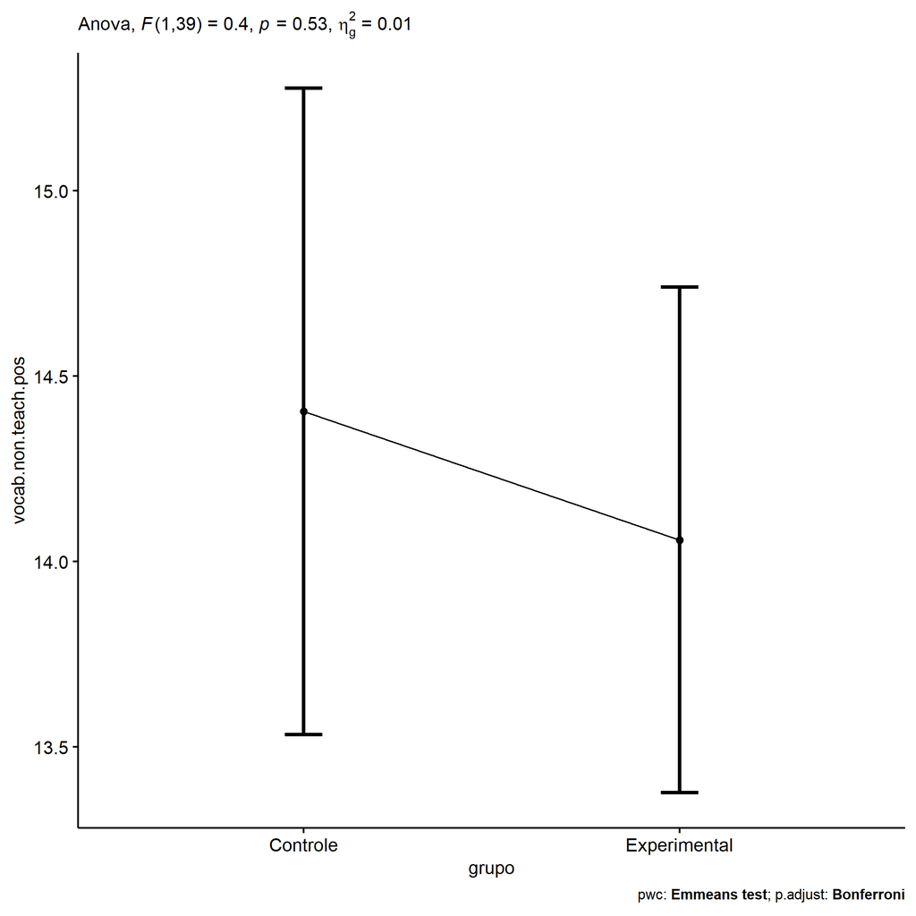

```r
if (!is.null(nrow(plots[["grupo"]]$data)))
  plots[["grupo"]] + ggplot2::scale_color_manual(values = color[["grupo"]])
```

```r
plots <- oneWayAncovaBoxPlots(
  wdat, "vocab.non.teach.pos", "grupo", aov, pwc, covar = "vocab.non.teach.pre",
  theme = "classic", color = color[["grupo"]],
  subtitle = which(aov$Effect == "grupo"))
```

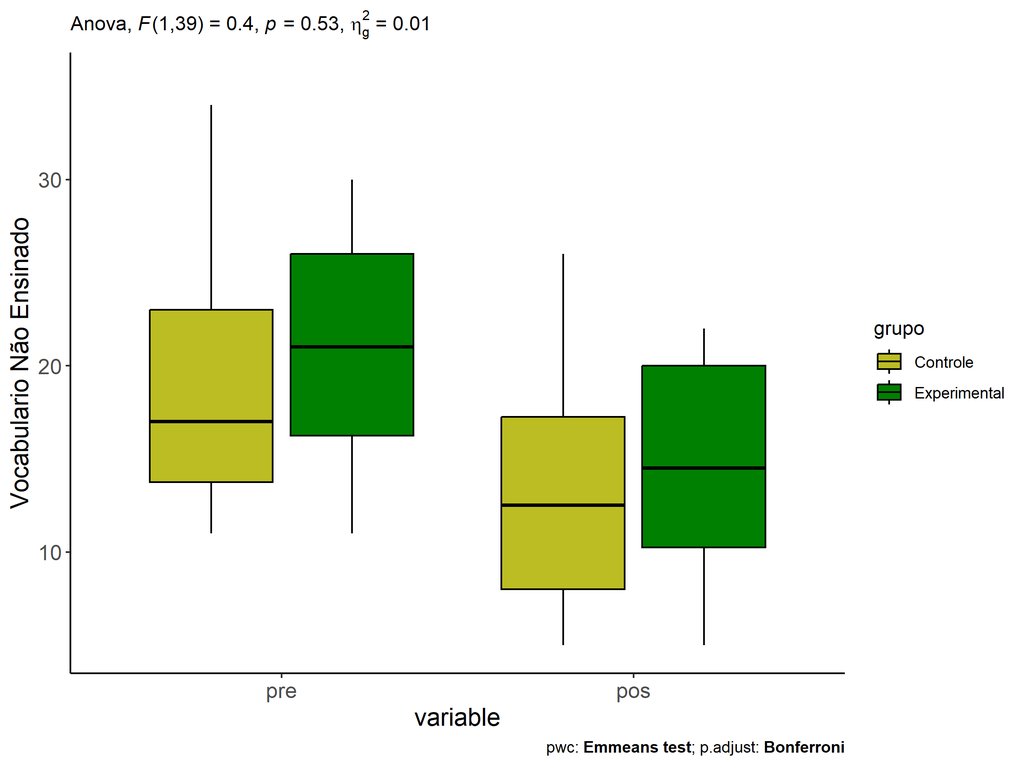

```r
if (length(unique(wdat[["grupo"]])) > 1)
  plots[["grupo"]] + ggplot2::ylab("Vocabulario Não Ensinado") + ggplot2::scale_x_discrete(labels=c('pre', 'pos'))
```

```r
if (length(unique(wdat.long[["grupo"]])) > 1)
  plots <- oneWayAncovaBoxPlots(
    wdat.long, "vocab.non.teach", "grupo", aov, pwc.long, pre.post = "time",
    theme = "classic", color = color$prepost)
```

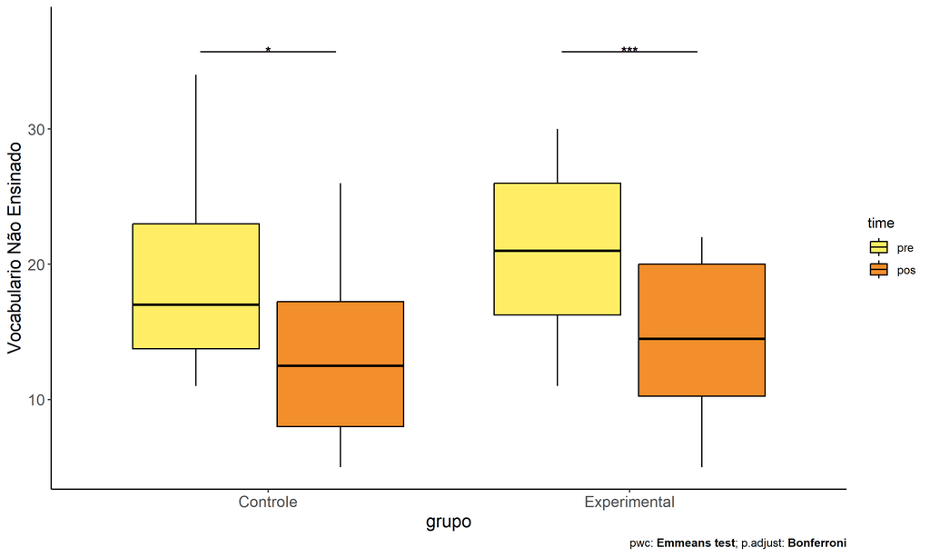

```r
if (length(unique(wdat.long[["grupo"]])) > 1)
  plots[["grupo"]] + ggplot2::ylab("Vocabulario Não Ensinado")
```

### Checking linearity assumption

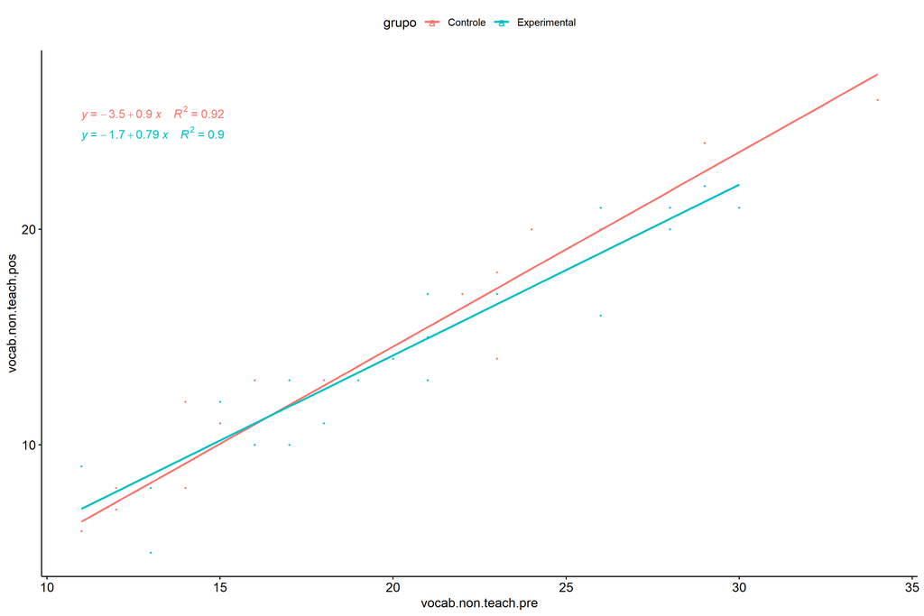

```r
ggscatter(wdat, x = "vocab.non.teach.pre", y = "vocab.non.teach.pos", size = 0.5,
          color = "grupo", add = "reg.line")+
  stat_regline_equation(
    aes(label =  paste(..eq.label.., ..rr.label.., sep = "~~~~"), color = grupo)
  )
```

### Checking normality and homogeneity

```r
res <- augment(lm(vocab.non.teach.pos ~ vocab.non.teach.pre + grupo, data = wdat))
```

```r
shapiro_test(res$.resid)
```

```
## # A tibble: 1 × 3
##   variable   statistic p.value
##   <chr>          <dbl>   <dbl>
## 1 res$.resid     0.957   0.120
```

```r
levene_test(res, .resid ~ grupo)
```

```
## # A tibble: 1 × 4
##     df1   df2 statistic     p
##   <int> <int>     <dbl> <dbl>
## 1     1    40     0.332 0.567
```

# ANCOVA and Pairwise for two factors **grupo:Sexo**

## Without remove non-normal data

```r
pdat = remove_group_data(dat[!is.na(dat[["grupo"]]) & !is.na(dat[["Sexo"]]),], "vocab.non.teach.pos", c("grupo","Sexo"))

pdat.long <- rbind(pdat[,c("id","grupo","Sexo")], pdat[,c("id","grupo","Sexo")])
pdat.long[["time"]] <- c(rep("pre", nrow(pdat)), rep("pos", nrow(pdat)))
pdat.long[["time"]] <- factor(pdat.long[["time"]], c("pre","pos"))
pdat.long[["vocab.non.teach"]] <- c(pdat[["vocab.non.teach.pre"]], pdat[["vocab.non.teach.pos"]])

aov = anova_test(pdat, vocab.non.teach.pos ~ vocab.non.teach.pre + grupo*Sexo)
laov[["grupo:Sexo"]] <- get_anova_table(aov)
```

```r
pwcs <- list()
pwcs[["Sexo"]] <- emmeans_test(
  group_by(pdat, grupo), vocab.non.teach.pos ~ Sexo,
  covariate = vocab.non.teach.pre, p.adjust.method = "bonferroni")
pwcs[["grupo"]] <- emmeans_test(
  group_by(pdat, Sexo), vocab.non.teach.pos ~ grupo,
  covariate = vocab.non.teach.pre, p.adjust.method = "bonferroni")

pwc <- plyr::rbind.fill(pwcs[["grupo"]], pwcs[["Sexo"]])
pwc <- pwc[,c("grupo","Sexo", colnames(pwc)[!colnames(pwc) %in% c("grupo","Sexo")])]
```

```r
pwc.long <- emmeans_test(dplyr::group_by_at(pdat.long, c("grupo","Sexo")),
                         vocab.non.teach ~ time,
                         p.adjust.method = "bonferroni")
lpwc[["grupo:Sexo"]] <- plyr::rbind.fill(pwc, pwc.long)
```

```r
ds <- get.descriptives(pdat, "vocab.non.teach.pos", c("grupo","Sexo"), covar = "vocab.non.teach.pre")
ds <- merge(ds[ds$variable != "vocab.non.teach.pre",],
            ds[ds$variable == "vocab.non.teach.pre", !colnames(ds) %in% c("variable")],
            by = c("grupo","Sexo"), all.x = T, suffixes = c("", ".vocab.non.teach.pre"))
ds <- merge(get_emmeans(pwcs[["grupo"]]), ds, by = c("grupo","Sexo"), suffixes = c(".emms", ""))
ds <- ds[,c("grupo","Sexo","n","mean.vocab.non.teach.pre","se.vocab.non.teach.pre","mean","se","emmean","se.emms")]

colnames(ds) <- c("grupo","Sexo", "N", paste0(c("M","SE")," (pre)"),
                  paste0(c("M","SE"), " (unadj)"), paste0(c("M", "SE"), " (adj)"))

lemms[["grupo:Sexo"]] <- ds
```

## Computing ANCOVA and PairWise After removing non-normal data (OK)

```r
wdat = pdat

res = residuals(lm(vocab.non.teach.pos ~ vocab.non.teach.pre + grupo*Sexo, data = wdat))
non.normal = getNonNormal(res, wdat$id, plimit = 0.05)

wdat = wdat[!wdat$id %in% non.normal,]

wdat.long <- rbind(wdat[,c("id","grupo","Sexo")], wdat[,c("id","grupo","Sexo")])
wdat.long[["time"]] <- c(rep("pre", nrow(wdat)), rep("pos", nrow(wdat)))
wdat.long[["time"]] <- factor(wdat.long[["time"]], c("pre","pos"))
wdat.long[["vocab.non.teach"]] <- c(wdat[["vocab.non.teach.pre"]], wdat[["vocab.non.teach.pos"]])


ldat[["grupo:Sexo"]] = wdat

(non.normal)
```

```
##  [1] "P983"  "P3042" "P1831" "P1966" "P1936" "P3038" "P2955" "P3548" "P916"  "P3097" "P2957" "P913"
```

```r
aov = anova_test(wdat, vocab.non.teach.pos ~ vocab.non.teach.pre + grupo*Sexo)
laov[["grupo:Sexo"]] <- merge(get_anova_table(aov), laov[["grupo:Sexo"]], by="Effect", suffixes = c("","'"))

(df = get_anova_table(aov))
```

```
## ANOVA Table (type II tests)
##
##                Effect DFn DFd       F        p p<.05   ges
## 1 vocab.non.teach.pre   1 331 680.789 2.61e-82     * 0.673
## 2               grupo   1 331   2.681 1.03e-01       0.008
## 3                Sexo   1 331   1.896 1.69e-01       0.006
## 4          grupo:Sexo   1 331   3.016 8.30e-02       0.009
```

| Effect | DFn | DFd | F | p | p<.05 | ges |
| --- | --- | --- | --- | --- | --- | --- |
| vocab.non.teach.pre | 1 | 331 | 680.789 | 0.000 | * | 0.673 |
| grupo | 1 | 331 | 2.681 | 0.103 |  | 0.008 |
| Sexo | 1 | 331 | 1.896 | 0.169 |  | 0.006 |
| grupo:Sexo | 1 | 331 | 3.016 | 0.083 |  | 0.009 |

```r
pwcs <- list()
pwcs[["Sexo"]] <- emmeans_test(
  group_by(wdat, grupo), vocab.non.teach.pos ~ Sexo,
  covariate = vocab.non.teach.pre, p.adjust.method = "bonferroni")
pwcs[["grupo"]] <- emmeans_test(
  group_by(wdat, Sexo), vocab.non.teach.pos ~ grupo,
  covariate = vocab.non.teach.pre, p.adjust.method = "bonferroni")

pwc <- plyr::rbind.fill(pwcs[["grupo"]], pwcs[["Sexo"]])
pwc <- pwc[,c("grupo","Sexo", colnames(pwc)[!colnames(pwc) %in% c("grupo","Sexo")])]
```

| grupo | Sexo | term | .y. | group1 | group2 | df | statistic | p | p.adj | p.adj.signif |
| --- | --- | --- | --- | --- | --- | --- | --- | --- | --- | --- |
|  | F | vocab.non.teach.pre*grupo | vocab.non.teach.pos | Controle | Experimental | 331 | 0.061 | 0.951 | 0.951 | ns |
|  | M | vocab.non.teach.pre*grupo | vocab.non.teach.pos | Controle | Experimental | 331 | 2.386 | 0.018 | 0.018 | * |
| Controle |  | vocab.non.teach.pre*Sexo | vocab.non.teach.pos | F | M | 331 | -0.403 | 0.687 | 0.687 | ns |
| Experimental |  | vocab.non.teach.pre*Sexo | vocab.non.teach.pos | F | M | 331 | 2.179 | 0.030 | 0.030 | * |

```r
pwc.long <- emmeans_test(dplyr::group_by_at(wdat.long, c("grupo","Sexo")),
                         vocab.non.teach ~ time,
                         p.adjust.method = "bonferroni")
lpwc[["grupo:Sexo"]] <- merge(plyr::rbind.fill(pwc, pwc.long), lpwc[["grupo:Sexo"]], by=c("grupo","Sexo","term",".y.","group1","group2"), suffixes = c("","'"))
```

| grupo | Sexo | term | .y. | group1 | group2 | df | statistic | p | p.adj | p.adj.signif |
| --- | --- | --- | --- | --- | --- | --- | --- | --- | --- | --- |
| Controle | F | time | vocab.non.teach | pre | pos | 664 | -1.038 | 0.300 | 0.300 | ns |
| Controle | M | time | vocab.non.teach | pre | pos | 664 | -1.462 | 0.144 | 0.144 | ns |
| Experimental | F | time | vocab.non.teach | pre | pos | 664 | -0.992 | 0.321 | 0.321 | ns |
| Experimental | M | time | vocab.non.teach | pre | pos | 664 | 0.256 | 0.798 | 0.798 | ns |

```r
ds <- get.descriptives(wdat, "vocab.non.teach.pos", c("grupo","Sexo"), covar = "vocab.non.teach.pre")
ds <- merge(ds[ds$variable != "vocab.non.teach.pre",],
            ds[ds$variable == "vocab.non.teach.pre", !colnames(ds) %in% c("variable")],
            by = c("grupo","Sexo"), all.x = T, suffixes = c("", ".vocab.non.teach.pre"))
ds <- merge(get_emmeans(pwcs[["grupo"]]), ds, by = c("grupo","Sexo"), suffixes = c(".emms", ""))
ds <- ds[,c("grupo","Sexo","n","mean.vocab.non.teach.pre","se.vocab.non.teach.pre","mean","se","emmean","se.emms")]

colnames(ds) <- c("grupo","Sexo", "N", paste0(c("M","SE")," (pre)"),
                  paste0(c("M","SE"), " (unadj)"), paste0(c("M", "SE"), " (adj)"))

lemms[["grupo:Sexo"]] <- merge(ds, lemms[["grupo:Sexo"]], by=c("grupo","Sexo"), suffixes = c("","'"))
```

| grupo | Sexo | N | M (pre) | SE (pre) | M (unadj) | SE (unadj) | M (adj) | SE (adj) |
| --- | --- | --- | --- | --- | --- | --- | --- | --- |
| Controle | F | 85 | 21.459 | 0.759 | 22.565 | 0.734 | 22.389 | 0.431 |
| Controle | M | 63 | 19.079 | 0.997 | 20.889 | 0.966 | 22.657 | 0.505 |
| Experimental | F | 97 | 21.897 | 0.636 | 22.887 | 0.637 | 22.353 | 0.404 |
| Experimental | M | 91 | 21.846 | 0.726 | 21.582 | 0.756 | 21.091 | 0.417 |

### Plots for ancova

```r
plots <- twoWayAncovaPlots(
  wdat, "vocab.non.teach.pos", c("grupo","Sexo"), aov, pwcs, addParam = c("mean_se"),
  font.label.size=10, step.increase=0.05, p.label="p.adj",
  subtitle = which(aov$Effect == "grupo:Sexo"))
```

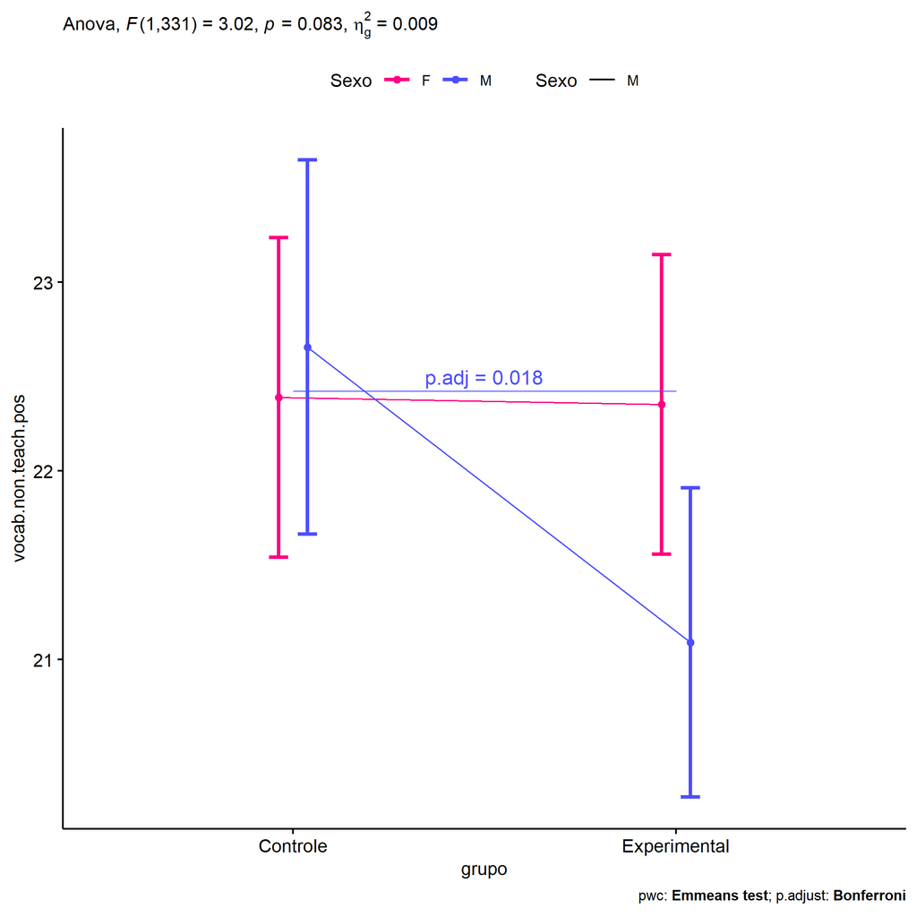

```r
if (!is.null(plots[["grupo"]]))
  plots[["grupo"]] + ggplot2::scale_color_manual(values = color[["Sexo"]])
```

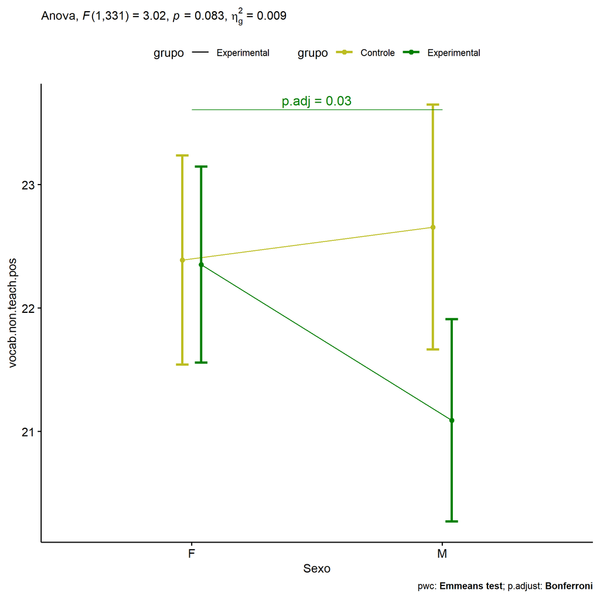

```r
if (!is.null(plots[["Sexo"]]))
  plots[["Sexo"]] + ggplot2::scale_color_manual(values = color[["grupo"]])
```

```r
plots <- twoWayAncovaBoxPlots(
  wdat, "vocab.non.teach.pos", c("grupo","Sexo"), aov, pwcs, covar = "vocab.non.teach.pre",
  theme = "classic", color = color[["grupo:Sexo"]],
  subtitle = which(aov$Effect == "grupo:Sexo"))
```

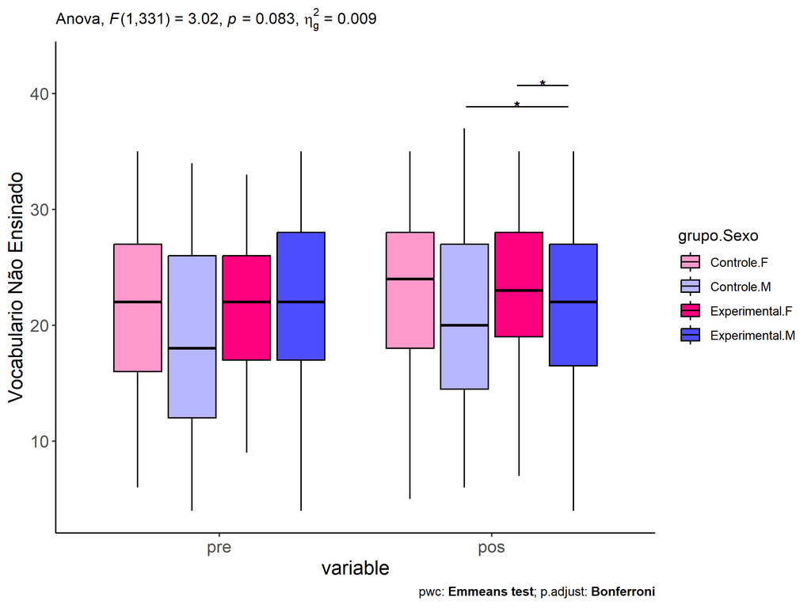

```r
plots[["grupo:Sexo"]] + ggplot2::ylab("Vocabulario Não Ensinado") + ggplot2::scale_x_discrete(labels=c('pre', 'pos'))
```

```r
plots <- twoWayAncovaBoxPlots(
  wdat.long, "vocab.non.teach", c("grupo","Sexo"), aov, pwc.long, pre.post = "time",
  theme = "classic", color = color$prepost)
```

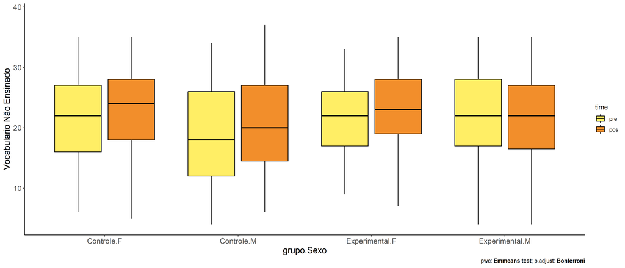

```r
plots[["grupo:Sexo"]] + ggplot2::ylab("Vocabulario Não Ensinado")
```

### Checking linearity assumption

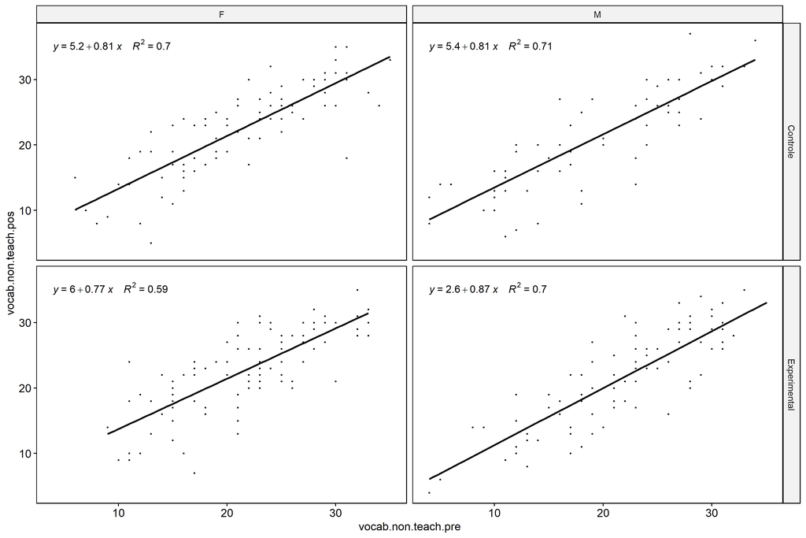

```r
ggscatter(wdat, x = "vocab.non.teach.pre", y = "vocab.non.teach.pos", size = 0.5,
          facet.by = c("grupo","Sexo"), add = "reg.line")+
  stat_regline_equation(
    aes(label =  paste(..eq.label.., ..rr.label.., sep = "~~~~"))
  )
```

### Checking normality and homogeneity

```r
res <- augment(lm(vocab.non.teach.pos ~ vocab.non.teach.pre + grupo*Sexo, data = wdat))
```

```r
shapiro_test(res$.resid)
```

```
## # A tibble: 1 × 3
##   variable   statistic p.value
##   <chr>          <dbl>   <dbl>
## 1 res$.resid     0.992  0.0759
```

```r
levene_test(res, .resid ~ grupo*Sexo)
```

```
## # A tibble: 1 × 4
##     df1   df2 statistic     p
##   <int> <int>     <dbl> <dbl>
## 1     3   332     0.509 0.676
```

# ANCOVA and Pairwise for two factors **grupo:Zona**

## Without remove non-normal data

```r
pdat = remove_group_data(dat[!is.na(dat[["grupo"]]) & !is.na(dat[["Zona"]]),], "vocab.non.teach.pos", c("grupo","Zona"))

pdat.long <- rbind(pdat[,c("id","grupo","Zona")], pdat[,c("id","grupo","Zona")])
pdat.long[["time"]] <- c(rep("pre", nrow(pdat)), rep("pos", nrow(pdat)))
pdat.long[["time"]] <- factor(pdat.long[["time"]], c("pre","pos"))
pdat.long[["vocab.non.teach"]] <- c(pdat[["vocab.non.teach.pre"]], pdat[["vocab.non.teach.pos"]])

aov = anova_test(pdat, vocab.non.teach.pos ~ vocab.non.teach.pre + grupo*Zona)
laov[["grupo:Zona"]] <- get_anova_table(aov)
```

```r
pwcs <- list()
pwcs[["Zona"]] <- emmeans_test(
  group_by(pdat, grupo), vocab.non.teach.pos ~ Zona,
  covariate = vocab.non.teach.pre, p.adjust.method = "bonferroni")
pwcs[["grupo"]] <- emmeans_test(
  group_by(pdat, Zona), vocab.non.teach.pos ~ grupo,
  covariate = vocab.non.teach.pre, p.adjust.method = "bonferroni")

pwc <- plyr::rbind.fill(pwcs[["grupo"]], pwcs[["Zona"]])
pwc <- pwc[,c("grupo","Zona", colnames(pwc)[!colnames(pwc) %in% c("grupo","Zona")])]
```

```r
pwc.long <- emmeans_test(dplyr::group_by_at(pdat.long, c("grupo","Zona")),
                         vocab.non.teach ~ time,
                         p.adjust.method = "bonferroni")
lpwc[["grupo:Zona"]] <- plyr::rbind.fill(pwc, pwc.long)
```

```r
ds <- get.descriptives(pdat, "vocab.non.teach.pos", c("grupo","Zona"), covar = "vocab.non.teach.pre")
ds <- merge(ds[ds$variable != "vocab.non.teach.pre",],
            ds[ds$variable == "vocab.non.teach.pre", !colnames(ds) %in% c("variable")],
            by = c("grupo","Zona"), all.x = T, suffixes = c("", ".vocab.non.teach.pre"))
ds <- merge(get_emmeans(pwcs[["grupo"]]), ds, by = c("grupo","Zona"), suffixes = c(".emms", ""))
ds <- ds[,c("grupo","Zona","n","mean.vocab.non.teach.pre","se.vocab.non.teach.pre","mean","se","emmean","se.emms")]

colnames(ds) <- c("grupo","Zona", "N", paste0(c("M","SE")," (pre)"),
                  paste0(c("M","SE"), " (unadj)"), paste0(c("M", "SE"), " (adj)"))

lemms[["grupo:Zona"]] <- ds
```

## Computing ANCOVA and PairWise After removing non-normal data (OK)

```r
wdat = pdat

res = residuals(lm(vocab.non.teach.pos ~ vocab.non.teach.pre + grupo*Zona, data = wdat))
non.normal = getNonNormal(res, wdat$id, plimit = 0.05)

wdat = wdat[!wdat$id %in% non.normal,]

wdat.long <- rbind(wdat[,c("id","grupo","Zona")], wdat[,c("id","grupo","Zona")])
wdat.long[["time"]] <- c(rep("pre", nrow(wdat)), rep("pos", nrow(wdat)))
wdat.long[["time"]] <- factor(wdat.long[["time"]], c("pre","pos"))
wdat.long[["vocab.non.teach"]] <- c(wdat[["vocab.non.teach.pre"]], wdat[["vocab.non.teach.pos"]])


ldat[["grupo:Zona"]] = wdat

(non.normal)
```

```
## [1] "P983"  "P1831" "P1966" "P2957" "P976"  "P916"  "P3038" "P3042" "P1961"
```

```r
aov = anova_test(wdat, vocab.non.teach.pos ~ vocab.non.teach.pre + grupo*Zona)
laov[["grupo:Zona"]] <- merge(get_anova_table(aov), laov[["grupo:Zona"]], by="Effect", suffixes = c("","'"))

(df = get_anova_table(aov))
```

```
## ANOVA Table (type II tests)
##
##                Effect DFn DFd       F        p p<.05      ges
## 1 vocab.non.teach.pre   1 280 576.726 5.85e-70     * 0.673000
## 2               grupo   1 280   3.957 4.80e-02     * 0.014000
## 3                Zona   1 280   0.015 9.03e-01       0.000053
## 4          grupo:Zona   1 280   3.357 6.80e-02       0.012000
```

| Effect | DFn | DFd | F | p | p<.05 | ges |
| --- | --- | --- | --- | --- | --- | --- |
| vocab.non.teach.pre | 1 | 280 | 576.726 | 0.000 | * | 0.673 |
| grupo | 1 | 280 | 3.957 | 0.048 | * | 0.014 |
| Zona | 1 | 280 | 0.015 | 0.903 |  | 0.000 |
| grupo:Zona | 1 | 280 | 3.357 | 0.068 |  | 0.012 |

```r
pwcs <- list()
pwcs[["Zona"]] <- emmeans_test(
  group_by(wdat, grupo), vocab.non.teach.pos ~ Zona,
  covariate = vocab.non.teach.pre, p.adjust.method = "bonferroni")
pwcs[["grupo"]] <- emmeans_test(
  group_by(wdat, Zona), vocab.non.teach.pos ~ grupo,
  covariate = vocab.non.teach.pre, p.adjust.method = "bonferroni")

pwc <- plyr::rbind.fill(pwcs[["grupo"]], pwcs[["Zona"]])
pwc <- pwc[,c("grupo","Zona", colnames(pwc)[!colnames(pwc) %in% c("grupo","Zona")])]
```

| grupo | Zona | term | .y. | group1 | group2 | df | statistic | p | p.adj | p.adj.signif |
| --- | --- | --- | --- | --- | --- | --- | --- | --- | --- | --- |
|  | Rural | vocab.non.teach.pre*grupo | vocab.non.teach.pos | Controle | Experimental | 280 | 2.702 | 0.007 | 0.007 | ** |
|  | Urbana | vocab.non.teach.pre*grupo | vocab.non.teach.pos | Controle | Experimental | 280 | -0.109 | 0.913 | 0.913 | ns |
| Controle |  | vocab.non.teach.pre*Zona | vocab.non.teach.pos | Rural | Urbana | 280 | 1.310 | 0.191 | 0.191 | ns |
| Experimental |  | vocab.non.teach.pre*Zona | vocab.non.teach.pos | Rural | Urbana | 280 | -1.284 | 0.200 | 0.200 | ns |

```r
pwc.long <- emmeans_test(dplyr::group_by_at(wdat.long, c("grupo","Zona")),
                         vocab.non.teach ~ time,
                         p.adjust.method = "bonferroni")
lpwc[["grupo:Zona"]] <- merge(plyr::rbind.fill(pwc, pwc.long), lpwc[["grupo:Zona"]], by=c("grupo","Zona","term",".y.","group1","group2"), suffixes = c("","'"))
```

| grupo | Zona | term | .y. | group1 | group2 | df | statistic | p | p.adj | p.adj.signif |
| --- | --- | --- | --- | --- | --- | --- | --- | --- | --- | --- |
| Controle | Rural | time | vocab.non.teach | pre | pos | 562 | -1.575 | 0.116 | 0.116 | ns |
| Controle | Urbana | time | vocab.non.teach | pre | pos | 562 | -0.451 | 0.652 | 0.652 | ns |
| Experimental | Rural | time | vocab.non.teach | pre | pos | 562 | 0.064 | 0.949 | 0.949 | ns |
| Experimental | Urbana | time | vocab.non.teach | pre | pos | 562 | -0.540 | 0.589 | 0.589 | ns |

```r
ds <- get.descriptives(wdat, "vocab.non.teach.pos", c("grupo","Zona"), covar = "vocab.non.teach.pre")
ds <- merge(ds[ds$variable != "vocab.non.teach.pre",],
            ds[ds$variable == "vocab.non.teach.pre", !colnames(ds) %in% c("variable")],
            by = c("grupo","Zona"), all.x = T, suffixes = c("", ".vocab.non.teach.pre"))
ds <- merge(get_emmeans(pwcs[["grupo"]]), ds, by = c("grupo","Zona"), suffixes = c(".emms", ""))
ds <- ds[,c("grupo","Zona","n","mean.vocab.non.teach.pre","se.vocab.non.teach.pre","mean","se","emmean","se.emms")]

colnames(ds) <- c("grupo","Zona", "N", paste0(c("M","SE")," (pre)"),
                  paste0(c("M","SE"), " (unadj)"), paste0(c("M", "SE"), " (adj)"))

lemms[["grupo:Zona"]] <- merge(ds, lemms[["grupo:Zona"]], by=c("grupo","Zona"), suffixes = c("","'"))
```

| grupo | Zona | N | M (pre) | SE (pre) | M (unadj) | SE (unadj) | M (adj) | SE (adj) |
| --- | --- | --- | --- | --- | --- | --- | --- | --- |
| Controle | Rural | 74 | 20.743 | 0.817 | 22.541 | 0.807 | 23.323 | 0.466 |
| Controle | Urbana | 49 | 21.918 | 1.088 | 22.551 | 1.080 | 22.356 | 0.572 |
| Experimental | Rural | 90 | 21.722 | 0.718 | 21.656 | 0.750 | 21.624 | 0.422 |
| Experimental | Urbana | 72 | 22.444 | 0.743 | 23.069 | 0.761 | 22.437 | 0.472 |

### Plots for ancova

```r
plots <- twoWayAncovaPlots(
  wdat, "vocab.non.teach.pos", c("grupo","Zona"), aov, pwcs, addParam = c("mean_se"),
  font.label.size=10, step.increase=0.05, p.label="p.adj",
  subtitle = which(aov$Effect == "grupo:Zona"))
```

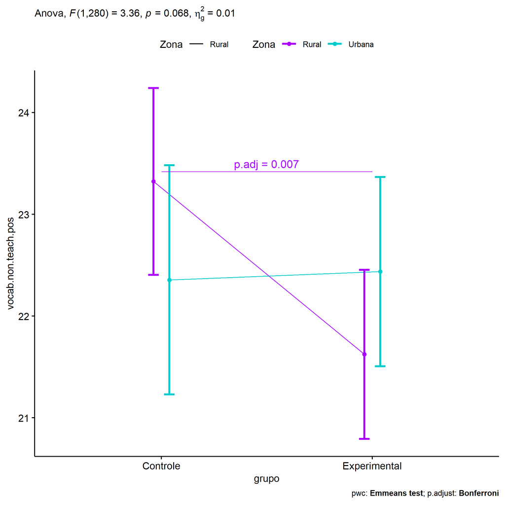

```r
if (!is.null(plots[["grupo"]]))
  plots[["grupo"]] + ggplot2::scale_color_manual(values = color[["Zona"]])
```

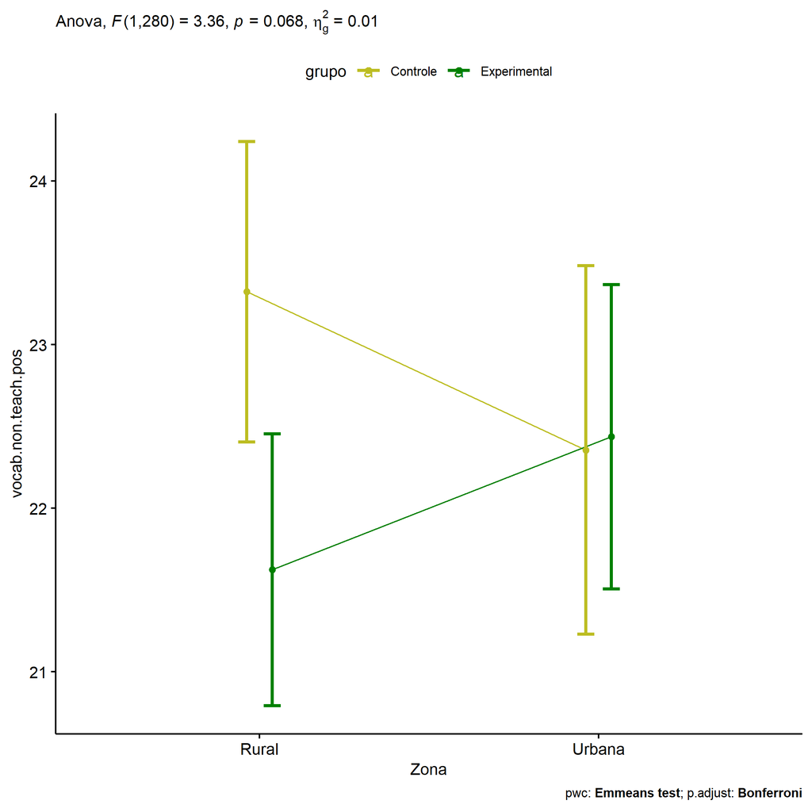

```r
if (!is.null(plots[["Zona"]]))
  plots[["Zona"]] + ggplot2::scale_color_manual(values = color[["grupo"]])
```

```r
plots <- twoWayAncovaBoxPlots(
  wdat, "vocab.non.teach.pos", c("grupo","Zona"), aov, pwcs, covar = "vocab.non.teach.pre",
  theme = "classic", color = color[["grupo:Zona"]],
  subtitle = which(aov$Effect == "grupo:Zona"))
```

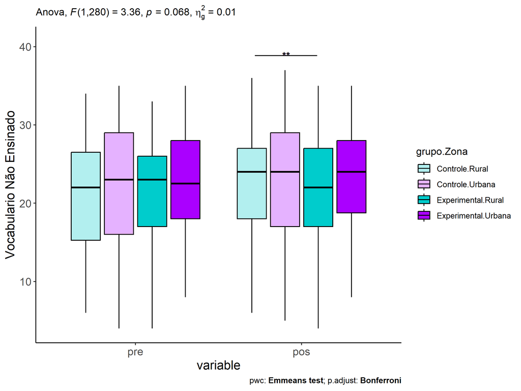

```r
plots[["grupo:Zona"]] + ggplot2::ylab("Vocabulario Não Ensinado") + ggplot2::scale_x_discrete(labels=c('pre', 'pos'))
```

```r
plots <- twoWayAncovaBoxPlots(
  wdat.long, "vocab.non.teach", c("grupo","Zona"), aov, pwc.long, pre.post = "time",
  theme = "classic", color = color$prepost)
```

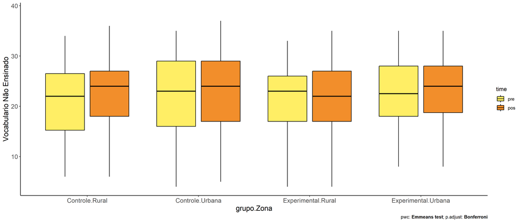

```r
plots[["grupo:Zona"]] + ggplot2::ylab("Vocabulario Não Ensinado")
```

### Checking linearity assumption

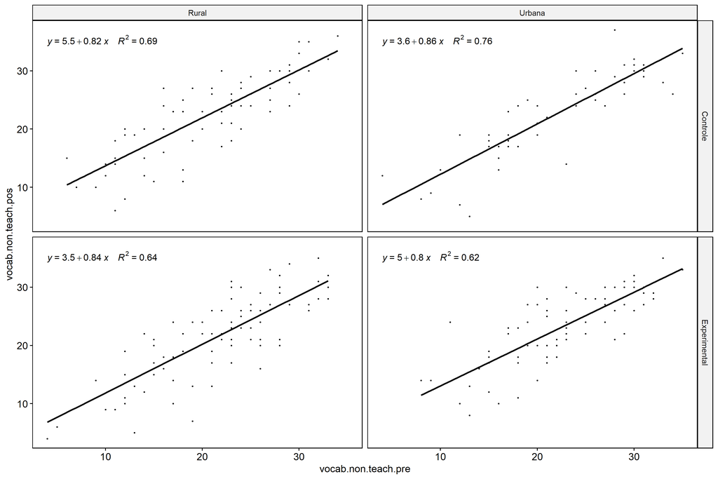

```r
ggscatter(wdat, x = "vocab.non.teach.pre", y = "vocab.non.teach.pos", size = 0.5,
          facet.by = c("grupo","Zona"), add = "reg.line")+
  stat_regline_equation(
    aes(label =  paste(..eq.label.., ..rr.label.., sep = "~~~~"))
  )
```

### Checking normality and homogeneity

```r
res <- augment(lm(vocab.non.teach.pos ~ vocab.non.teach.pre + grupo*Zona, data = wdat))
```

```r
shapiro_test(res$.resid)
```

```
## # A tibble: 1 × 3
##   variable   statistic p.value
##   <chr>          <dbl>   <dbl>
## 1 res$.resid     0.993   0.179
```

```r
levene_test(res, .resid ~ grupo*Zona)
```

```
## # A tibble: 1 × 4
##     df1   df2 statistic     p
##   <int> <int>     <dbl> <dbl>
## 1     3   281     0.907 0.438
```

# ANCOVA and Pairwise for two factors **grupo:Cor.Raca**

## Without remove non-normal data

```r
pdat = remove_group_data(dat[!is.na(dat[["grupo"]]) & !is.na(dat[["Cor.Raca"]]),], "vocab.non.teach.pos", c("grupo","Cor.Raca"))

pdat.long <- rbind(pdat[,c("id","grupo","Cor.Raca")], pdat[,c("id","grupo","Cor.Raca")])
pdat.long[["time"]] <- c(rep("pre", nrow(pdat)), rep("pos", nrow(pdat)))
pdat.long[["time"]] <- factor(pdat.long[["time"]], c("pre","pos"))
pdat.long[["vocab.non.teach"]] <- c(pdat[["vocab.non.teach.pre"]], pdat[["vocab.non.teach.pos"]])

aov = anova_test(pdat, vocab.non.teach.pos ~ vocab.non.teach.pre + grupo*Cor.Raca)
laov[["grupo:Cor.Raca"]] <- get_anova_table(aov)
```

```r
pwcs <- list()
pwcs[["Cor.Raca"]] <- emmeans_test(
  group_by(pdat, grupo), vocab.non.teach.pos ~ Cor.Raca,
  covariate = vocab.non.teach.pre, p.adjust.method = "bonferroni")
pwcs[["grupo"]] <- emmeans_test(
  group_by(pdat, Cor.Raca), vocab.non.teach.pos ~ grupo,
  covariate = vocab.non.teach.pre, p.adjust.method = "bonferroni")

pwc <- plyr::rbind.fill(pwcs[["grupo"]], pwcs[["Cor.Raca"]])
pwc <- pwc[,c("grupo","Cor.Raca", colnames(pwc)[!colnames(pwc) %in% c("grupo","Cor.Raca")])]
```

```r
pwc.long <- emmeans_test(dplyr::group_by_at(pdat.long, c("grupo","Cor.Raca")),
                         vocab.non.teach ~ time,
                         p.adjust.method = "bonferroni")
lpwc[["grupo:Cor.Raca"]] <- plyr::rbind.fill(pwc, pwc.long)
```

```r
ds <- get.descriptives(pdat, "vocab.non.teach.pos", c("grupo","Cor.Raca"), covar = "vocab.non.teach.pre")
ds <- merge(ds[ds$variable != "vocab.non.teach.pre",],
            ds[ds$variable == "vocab.non.teach.pre", !colnames(ds) %in% c("variable")],
            by = c("grupo","Cor.Raca"), all.x = T, suffixes = c("", ".vocab.non.teach.pre"))
ds <- merge(get_emmeans(pwcs[["grupo"]]), ds, by = c("grupo","Cor.Raca"), suffixes = c(".emms", ""))
ds <- ds[,c("grupo","Cor.Raca","n","mean.vocab.non.teach.pre","se.vocab.non.teach.pre","mean","se","emmean","se.emms")]

colnames(ds) <- c("grupo","Cor.Raca", "N", paste0(c("M","SE")," (pre)"),
                  paste0(c("M","SE"), " (unadj)"), paste0(c("M", "SE"), " (adj)"))

lemms[["grupo:Cor.Raca"]] <- ds
```

## Computing ANCOVA and PairWise After removing non-normal data (OK)

```r
wdat = pdat

res = residuals(lm(vocab.non.teach.pos ~ vocab.non.teach.pre + grupo*Cor.Raca, data = wdat))
non.normal = getNonNormal(res, wdat$id, plimit = 0.05)

wdat = wdat[!wdat$id %in% non.normal,]

wdat.long <- rbind(wdat[,c("id","grupo","Cor.Raca")], wdat[,c("id","grupo","Cor.Raca")])
wdat.long[["time"]] <- c(rep("pre", nrow(wdat)), rep("pos", nrow(wdat)))
wdat.long[["time"]] <- factor(wdat.long[["time"]], c("pre","pos"))
wdat.long[["vocab.non.teach"]] <- c(wdat[["vocab.non.teach.pre"]], wdat[["vocab.non.teach.pos"]])


ldat[["grupo:Cor.Raca"]] = wdat

(non.normal)
```

[output not shown]

```r
aov = anova_test(wdat, vocab.non.teach.pos ~ vocab.non.teach.pre + grupo*Cor.Raca)
laov[["grupo:Cor.Raca"]] <- merge(get_anova_table(aov), laov[["grupo:Cor.Raca"]], by="Effect", suffixes = c("","'"))

(df = get_anova_table(aov))
```

```
## ANOVA Table (type II tests)
##
##                Effect DFn DFd       F        p p<.05   ges
## 1 vocab.non.teach.pre   1 132 199.848 3.35e-28     * 0.602
## 2               grupo   1 132   6.168 1.40e-02     * 0.045
## 3            Cor.Raca   2 132   0.890 4.13e-01       0.013
## 4      grupo:Cor.Raca   1 132   2.550 1.13e-01       0.019
```

| Effect | DFn | DFd | F | p | p<.05 | ges |
| --- | --- | --- | --- | --- | --- | --- |
| vocab.non.teach.pre | 1 | 132 | 199.848 | 0.000 | * | 0.602 |
| grupo | 1 | 132 | 6.168 | 0.014 | * | 0.045 |
| Cor.Raca | 2 | 132 | 0.890 | 0.413 |  | 0.013 |
| grupo:Cor.Raca | 1 | 132 | 2.550 | 0.113 |  | 0.019 |

```r
pwcs <- list()
pwcs[["Cor.Raca"]] <- emmeans_test(
  group_by(wdat, grupo), vocab.non.teach.pos ~ Cor.Raca,
  covariate = vocab.non.teach.pre, p.adjust.method = "bonferroni")
pwcs[["grupo"]] <- emmeans_test(
  group_by(wdat, Cor.Raca), vocab.non.teach.pos ~ grupo,
  covariate = vocab.non.teach.pre, p.adjust.method = "bonferroni")

pwc <- plyr::rbind.fill(pwcs[["grupo"]], pwcs[["Cor.Raca"]])
pwc <- pwc[,c("grupo","Cor.Raca", colnames(pwc)[!colnames(pwc) %in% c("grupo","Cor.Raca")])]
```

| grupo | Cor.Raca | term | .y. | group1 | group2 | df | statistic | p | p.adj | p.adj.signif |
| --- | --- | --- | --- | --- | --- | --- | --- | --- | --- | --- |
|  | Branca | vocab.non.teach.pre*grupo | vocab.non.teach.pos | Controle | Experimental | 132 | 2.621 | 0.010 | 0.010 | ** |
|  | Indígena | vocab.non.teach.pre*grupo | vocab.non.teach.pos | Controle | Experimental |  |  |  |  |  |
|  | Parda | vocab.non.teach.pre*grupo | vocab.non.teach.pos | Controle | Experimental | 132 | 1.359 | 0.177 | 0.177 | ns |
| Controle |  | vocab.non.teach.pre*Cor.Raca | vocab.non.teach.pos | Branca | Indígena | 132 | -0.570 | 0.570 | 1.000 | ns |
| Controle |  | vocab.non.teach.pre*Cor.Raca | vocab.non.teach.pos | Branca | Parda | 132 | 0.121 | 0.904 | 1.000 | ns |
| Controle |  | vocab.non.teach.pre*Cor.Raca | vocab.non.teach.pos | Indígena | Parda | 132 | 0.696 | 0.488 | 1.000 | ns |
| Experimental |  | vocab.non.teach.pre*Cor.Raca | vocab.non.teach.pos | Branca | Indígena |  |  |  |  |  |
| Experimental |  | vocab.non.teach.pre*Cor.Raca | vocab.non.teach.pos | Branca | Parda | 132 | -1.959 | 0.052 | 0.052 | ns |
| Experimental |  | vocab.non.teach.pre*Cor.Raca | vocab.non.teach.pos | Indígena | Parda |  |  |  |  |  |

```r
pwc.long <- emmeans_test(dplyr::group_by_at(wdat.long, c("grupo","Cor.Raca")),
                         vocab.non.teach ~ time,
                         p.adjust.method = "bonferroni")
lpwc[["grupo:Cor.Raca"]] <- merge(plyr::rbind.fill(pwc, pwc.long), lpwc[["grupo:Cor.Raca"]], by=c("grupo","Cor.Raca","term",".y.","group1","group2"), suffixes = c("","'"))
```

| grupo | Cor.Raca | term | .y. | group1 | group2 | df | statistic | p | p.adj | p.adj.signif |
| --- | --- | --- | --- | --- | --- | --- | --- | --- | --- | --- |
| Controle | Branca | time | vocab.non.teach | pre | pos | 266 | -0.588 | 0.557 | 0.557 | ns |
| Controle | Indígena | time | vocab.non.teach | pre | pos | 266 | -0.758 | 0.449 | 0.449 | ns |
| Controle | Parda | time | vocab.non.teach | pre | pos | 266 | -1.139 | 0.256 | 0.256 | ns |
| Experimental | Branca | time | vocab.non.teach | pre | pos | 266 | 1.061 | 0.290 | 0.290 | ns |
| Experimental | Indígena | time | vocab.non.teach | pre | pos |  |  |  |  |  |
| Experimental | Parda | time | vocab.non.teach | pre | pos | 266 | -0.099 | 0.921 | 0.921 | ns |

```r
ds <- get.descriptives(wdat, "vocab.non.teach.pos", c("grupo","Cor.Raca"), covar = "vocab.non.teach.pre")
ds <- merge(ds[ds$variable != "vocab.non.teach.pre",],
            ds[ds$variable == "vocab.non.teach.pre", !colnames(ds) %in% c("variable")],
            by = c("grupo","Cor.Raca"), all.x = T, suffixes = c("", ".vocab.non.teach.pre"))
ds <- merge(get_emmeans(pwcs[["grupo"]]), ds, by = c("grupo","Cor.Raca"), suffixes = c(".emms", ""))
ds <- ds[,c("grupo","Cor.Raca","n","mean.vocab.non.teach.pre","se.vocab.non.teach.pre","mean","se","emmean","se.emms")]

colnames(ds) <- c("grupo","Cor.Raca", "N", paste0(c("M","SE")," (pre)"),
                  paste0(c("M","SE"), " (unadj)"), paste0(c("M", "SE"), " (adj)"))

lemms[["grupo:Cor.Raca"]] <- merge(ds, lemms[["grupo:Cor.Raca"]], by=c("grupo","Cor.Raca"), suffixes = c("","'"))
```

| grupo | Cor.Raca | N | M (pre) | SE (pre) | M (unadj) | SE (unadj) | M (adj) | SE (adj) |
| --- | --- | --- | --- | --- | --- | --- | --- | --- |
| Controle | Branca | 22 | 22.273 | 1.369 | 23.500 | 1.408 | 21.949 | 0.969 |
| Controle | Indígena | 8 | 20.375 | 1.917 | 23.000 | 2.315 | 23.013 | 1.596 |
| Controle | Parda | 44 | 18.864 | 1.115 | 20.545 | 1.266 | 21.804 | 0.686 |
| Experimental | Branca | 12 | 22.167 | 1.792 | 19.167 | 1.779 | 17.704 | 1.307 |
| Experimental | Parda | 52 | 20.481 | 0.900 | 20.615 | 0.889 | 20.542 | 0.626 |